# WS 2.1: Wiggles

## Part 2: Central Difference issues!

The discretization is unstable (regardless of the time step used), largely due to weighting equally the influence by adjacent volumes in the fluxes. The hyperbolic nature of the equation implies that more weight should be given to the upstream/upwind $\phi$ values.

You might think that the initial abrupt edges of the square wave is responsible for the instability. You can test this by replacing the square pulse with a smooth one.

**Task 2:** Run the 1D simulation again using a smooth pulse. You can do this by changing the value of `square` from `True` to `False`. Does the simulation work?

```python
square=False
x, p_all = run_simulation_1D(p0, c, L, Nx, T, Nt, dx, dt, central, square)
plot_1D_all()
```

```
Current variables values:
  p0 [---]: 2.00
  c  [m/s]: 5.00
  L  [ m ]: 2.0
  Nx [---]: 100.0
  T  [ s ]: 40.0
  Nt [---]: 100000.0
  dx [ m ]: 2.00e-02
  dt [ s ]: 4.00e-04
Using central difference?: True
Using square init. cond.?: False
CFL: 1.00e-01
```

```
interactive(children=(Play(value=0, description='step', max=99999), Output()), _dom_classes=('widget-interact'…
```

```
HBox(children=(IntSlider(value=0, max=99999),))
```

## Part 3: Upwind scheme

**Task 3.1:**

Derive the upwind scheme and apply Forward Euler to the resulting ODE. Then implement it in the function advection_1D. Re-run the analysis after setting the central flag to False.

```python
square=True
central=False

x, p_all = run_simulation_1D(p0, c, L, Nx, T, 10000, dx, dt, central, square)
plot_1D_all()
```

[output not shown]

**Task 3.2:**

```python
# you can change variable values and rerun the analysis here.
```

| $\Delta t$ | stable or unstable? |
| --- | --- |

## Part 4: False Diffusion

In the previous tasks, we saw how upwinding can be an effective way to handle the type of PDE we are studying (in this case hyperbolic). Now, we will consider *another* aspect of stability: that of the time integration scheme.

Let’s play with the code. In convective kinematics a von Neumann analysis on the advection equation suggests that the following must hold for stability: $$ CFL = \frac{c \Delta t}{\Delta x} \leq 1 $$

$CFL$ is the Courant–Friedrichs–Lewy condtion, a dimensionless quantity that relates the speed of information leaves a finite volume, relating speed to the ratio of time step duration and cell length. The ratio can provide us an indication of the inherent stability of explicit schemes.

**Task 4.1:** If you have not already done so, modify the function above to calculate the CFL and run the function `check_variables_1D()` to check the values. Evaluate the CFL for the time steps you tried in Task 3.2 and write them below, along with the statement of whether or not the scheme was stable.

*Write your CFL values here, along with the result:*

| CFL | $\Delta t$ | stable or unstable? |
| --- | --- | --- |

```python
choose_case = 5
p0, c, L, Nx, T, Nt, dx, dt, central, square = case_set(C[choose_case])
print(C[choose_case]['name'])
```

```
Case 5: this will show numerical diffusion, backward diff
```

```python
x, p_all = run_simulation_1D(p0, c, L, Nx, T, Nt, dx, dt, central, square)
plot_1D_all()
```

```
Current variables values:
  p0 [---]: 2.00
  c  [m/s]: 5.00
  L  [ m ]: 10.0
  Nx [---]: 100.0
  T  [ s ]: 4.0
  Nt [---]: 10000.0
  dx [ m ]: 1.00e-01
  dt [ s ]: 4.00e-04
Using central difference?: False
Using square init. cond.?: True
CFL: 2.00e-02
```

```
interactive(children=(Play(value=0, description='step', max=9999), Output()), _dom_classes=('widget-interact',…
```

```
HBox(children=(IntSlider(value=0, max=9999),))
```

**Task 4.2:**

Now use the CFL to compute the time step $\Delta t$ that defines the boundary between the stable and unstable region. Then re-run the analysis for this value, as well as a value that is slightly above and below that threshold $\Delta t$.

```python
# SOLUTION
```

### So you think everything is stable and perfect, right?

Based on the previous task, it looks like we have a good handle on this problem, and are able to use the CFL to set up a reliable numerical scheme for all sorts of complex problems---right?!

**WRONG!**

Remember, in this problem we are dealing with single "wave" propagating at a *constant* speed. In practice we apply numerical schemes to more complex methods. For example, most problems consider *variable* speed/velocity in more than one dimension. When this is the case, the problem cannot be described by a single CFL value! As a rule of thumb, a modeller would then choose a conservative CFL value, determined by the largest expected flow velocities (in the case of a regular mesh).

Let's apply this concept by using a CFL condition of 0.8 to visualize the impact on the numerical solution.

**Task 4.3:**

Find $\Delta t$ such that CFL is 0.8 and re-run the analysis. What do you observe?

Make sure you look at the complete solution, not just the first few steps.

```python
# SOLUTION
```

**Task 4.4:**

Describe what you observe in the result of the previous task and state (yes/no) whether or not this should be expected, given the PDE we are solving. Explain your answer in a couple sentences.

**Solution:**

The phenomenon you saw in the previous task is numerical, or false diffusion. ...

No!

- we observe the wave diffuses
- our PDE only considers convection
- where does this come from?!

## Part 5: 2D Implementation in Python

**Task 5.1:** Apply FVM by hand to the 2D advection equation. The volumes are rectangular. This is a good example of an exam problem.

$$ \frac{\partial \phi}{\partial t} + c_x\frac{\partial \phi}{\partial x} + c_y\frac{\partial \phi}{\partial y} = 0 $$

**Task 5.2:** The code is set up in a very similar way to the 1D case above. Use it to explore how the advection problem works in 2D! In particular, see if you observe the effect called "numerical diffusion" --- when the numerical scheme causes the square pulse to "diffuse" into a bell shaped surface. Even though only the advection term was implmented!

The initial values of the variables below will result in numerical instability. See if you can fix it!

```python
p0 = 2.0
cx = 5.0
cy = 5.0

Lx = 2.0
Nx = 100
Ly = 2.0
Ny = 100
T = 40
Nt =  900

dx = Lx/Nx
dy = Ly/Ny
dt = T/Nt

central = True
```

```python
def initialize_2D(p0, Lx, Nx, Ly, Ny, T, Nt):
    x = np.linspace(dx/2, Lx - dx/2, Nx)
    y = np.linspace(dy/2, Ly - dx/2, Ny)
    X, Y = np.meshgrid(x, y)

    # Initialise domain: cubic pulse with p0 between 0.5 and 1
    p_init = np.zeros((Nx, Ny))
    p_init[int(0.5/dx):int(1/dx + 1), int(0.5/dy):int(1/dy + 1)] = p0

    p_all = np.zeros((Nt + 1, Nx, Ny))
    p_all[0] = p_init
    return X, Y, p_all

def advection_2D(p, cx, cy, Nx, Ny, dx, dy, dt, central=True):

    p_new = np.ones((Nx,Ny))

    for i in range(0, Nx):
        for j in range(0, Ny):
            if central:
                p_new[i-1,j-1] = (p[i-1,j-1]
                                  - 0.5*(cx*dt/dx)*(p[i,j-1] - p[i-2,j-1])
                                  - 0.5*(cy*dt/dy)*(p[i-1,j] - p[i-1,j-2]))
            else:
                p_new[i, j] = (p[i, j] - (cx*dt/dx)*(p[i, j] - p[i - 1, j])
                                       - (cy*dt/dy)*(p[i, j] - p[i, j - 1]))
    return p_new

def run_simulation_2D(p0, cx, cy, Lx, Nx, Ly, Ny,
                      T, Nt, dx, dy, dt, central=True):

    X, Y, p_all = initialize_2D(p0, Lx, Nx, Ly, Ny, T, Nt)

    for t in range(Nt):
        p = advection_2D(p_all[t], cx, cy, Nx, Ny,
                         dx, dy, dt, central=central)
        p_all[t + 1] = p

    return X, Y, p_all

def plot_2D(p, X, Y, step=0):
    'Create 2D plot, X and Y are formatted as meshgrid.'''
    fig = plt.figure(figsize=(11, 7), dpi=100)
    ax = fig.add_subplot(111, projection='3d')
    ax.set_xlabel('x [m]')
    ax.set_ylabel('y [m]')
    ax.set_zlabel('$\phi$ [-]')
    ax.set_title('Advection in 2D')
    surf = ax.plot_surface(X, Y, p[step],
                           cmap='Blues', rstride=2, cstride=2)
    fig.colorbar(surf, shrink=0.5, aspect=5)
    plt.show()

def plot_2D_all():
    check_variables_2D()

    play = widgets.Play(min=0, max=Nt-1, step=1, value=0,
                        interval=100, disabled=False)
    slider = widgets.IntSlider(min=0, max=Nt-1,
                               step=1, value=0)
    widgets.jslink((play, 'value'), (slider, 'value'))

    interact(plot_2D,
             p=fixed(p_all),
             X=fixed(X),
             Y=fixed(Y),
             step=play)

    return widgets.HBox([slider])

def check_variables_2D():
    print('Current variables values:')
    print(f'  p0 [---]: {p0:0.2f}')
    print(f'  cx [m/s]: {cx:0.2f}')
    print(f'  cy [m/s]: {cy:0.2f}')
    print(f'  Lx [ m ]: {Lx:0.1f}')
    print(f'  Nx [---]: {Nx:0.1f}')
    print(f'  Ly [ m ]: {Ly:0.1f}')
    print(f'  Ny [---]: {Ny:0.1f}')
    print(f'  T  [ s ]: {T:0.1f}')
    print(f'  Nt [---]: {Nt:0.1f}')
    print(f'  dx [ m ]: {dx:0.2e}')
    print(f'  dy [ m ]: {dy:0.2e}')
    print(f'  dt [ s ]: {dt:0.2e}')
    print(f'Using central difference?: {central}')
    print(f'Solution shape p_all[t_i]: ({Nx}, {Ny})')
    print(f'Total time steps in p_all: {Nt+1}')
    print(f'CFL, direction x: {cx*dt/dx:.2e}')
    print(f'CFL, direction y: {cy*dt/dy:.2e}')
```

Here you can check the Python variable assignments and visualize the initial conditions in the plot. Notice that we already redefine the time parameters to give a CFL of less than 1, in both directions.

```
Current variables values:
  p0 [---]: 2.00
  cx [m/s]: 5.00
  cy [m/s]: 5.00
  Lx [ m ]: 2.0
  Nx [---]: 100.0
  Ly [ m ]: 2.0
  Ny [---]: 100.0
  T  [ s ]: 1.0
  Nt [---]: 1000.0
  dx [ m ]: 2.00e-02
  dy [ m ]: 2.00e-02
  dt [ s ]: 1.00e-03
Using central difference?: True
Solution shape p_all[t_i]: (100, 100)
Total time steps in p_all: 1001
CFL, direction x: 2.50e-01
CFL, direction y: 2.50e-01
```

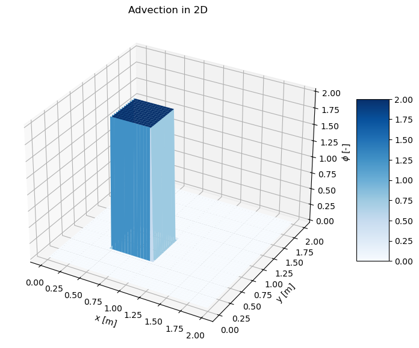

```python
T = 1
Nt =  1000
dt = T/Nt
check_variables_2D()
X, Y, p_all = initialize_2D(p0, Lx, Nx, Ly, Ny, T, Nt)
plot_2D(p_all, X, Y)
```

By default the central difference scheme is used, so you should see the numerical instability just as we did before in the 1D case.

```python
X, Y, p_all = run_simulation_2D(p0, cx, cy, Lx, Nx, Ly, Ny, T, Nt, dx, dy, dt, central)
plot_2D_all()
```

```
Current variables values:
  p0 [---]: 2.00
  cx [m/s]: 5.00
  cy [m/s]: 5.00
  Lx [ m ]: 2.0
  Nx [---]: 100.0
  Ly [ m ]: 2.0
  Ny [---]: 100.0
  T  [ s ]: 1.0
  Nt [---]: 1000.0
  dx [ m ]: 2.00e-02
  dy [ m ]: 2.00e-02
  dt [ s ]: 1.00e-03
Using central difference?: True
Solution shape p_all[t_i]: (100, 100)
Total time steps in p_all: 1001
CFL, direction x: 2.50e-01
CFL, direction y: 2.50e-01
```

```
interactive(children=(Play(value=0, description='step', max=999), Output()), _dom_classes=('widget-interact',)…
```

```
HBox(children=(IntSlider(value=0, max=999),))
```

Switching to the upwind scheme gives a stable solution. Note the numerical diffusion (change from cubic to bell shape). Also, as the edges of the bell shape spread outside of the X-Y domain, you will see them appear on the corners: this is a result of the fact that the iteration loops over X and Y in the meshgrid format don't properly find the "neighbor" volumes. To understand this, refer to the textbook where the matrix form of the 2D solution is presented and see how the index of the neighbor volumes is not sequential as in the for loops.

```python
X, Y, p_all = run_simulation_2D(p0, cx, cy, Lx, Nx, Ly, Ny, T, Nt, dx, dy, dt, central=False)
plot_2D_all()
```

```
Current variables values:
  p0 [---]: 2.00
  cx [m/s]: 5.00
  cy [m/s]: 5.00
  Lx [ m ]: 2.0
  Nx [---]: 100.0
  Ly [ m ]: 2.0
  Ny [---]: 100.0
  T  [ s ]: 1.0
  Nt [---]: 1000.0
  dx [ m ]: 2.00e-02
  dy [ m ]: 2.00e-02
  dt [ s ]: 1.00e-03
Using central difference?: True
Solution shape p_all[t_i]: (100, 100)
Total time steps in p_all: 1001
CFL, direction x: 2.50e-01
CFL, direction y: 2.50e-01
```

```
interactive(children=(Play(value=0, description='step', max=999), Output()), _dom_classes=('widget-interact',)…
```

```
HBox(children=(IntSlider(value=0, max=999),))
```

**End of notebook.**

By [MUDE Team](http://mude.citg.tudelft.nl/) © 2024 TU Delft. [CC BY 4.0](http://creativecommons.org/licenses/by/4.0/).